# Soc 506 R lab: setup and expectations

Connor Gilroy

2020-03-31

# Zoom norms

- Please mute your audio unless you need to speak
- I encourage you to use the chat to ask questions as well
- Labs will be recorded, office hours will not be
- I’ll enable participant screensharing later in lab, and for office hours

# Access

**You will need access to a computer than can run R.**

Two options:

1. install R + RStudio on your own machine
   - R: https://cloud.r-project.org/
   - RStudio: https://rstudio.com/products/rstudio/download/
2. log into the CSDE server using remote desktop
   - https://csde.washington.edu/computing/resources/

I recommend using a local install if you can.

# Expectations

**We want all students to use the same workflow for assignment submission.**

1. RMarkdown
   - You’ll write your code and text in an .Rmd file
   - You’ll submit an .html or .pdf file on Canvas  
     (If you haven’t done this before, use HTML output)
2. Project organization
   - You’ll associate each lab or homework with its own `.Rproj` file
   - You’ll create subfolders for `data/` and other files as needed
   - You should also consider organizing all of your folders and files for the class (see Zack’s example for a model)
3. Files from GitHub
   - You’ll download lab and homework files from a repository Zack made on GitHub: https://github.com/zalmquist/SOC506/
   - This includes an RMarkdown template for homework submission (see below)
   - You don’t have to use git or have a GitHub account, but you can

# GitHub demo

Let’s go to https://github.com/zalmquist/SOC506/ and download the course files. Expect them to update later!

# RMarkdown syntax

Use headers (#, ##, ###, …), formatting (**bold**, *italics*), lists, etc., to organize your text.

Something that may be new to you: **math syntax**. You can use `$` or `$$` to write mathematical symbols (written with a backslash) and equations.

Equations on their own lines:

$$y \sim \mathcal{N}(\mu, \sigma)$$
$$\mu = X \beta$$

Inline math can be written like this: $log(\mathcal{L})$, for a log-likelihood.

For more: https://bookdown.org/yihui/rmarkdown/markdown-syntax.html#math-expressions

# R basics

Load packages we’ll need:

```r
library(tidyverse)
```

Generate some random data:

```r
set.seed(20200331)
nsims <- 1000
x <- rnorm(nsims, mean = 100, sd = 10)
beta <- 3
epsilon <- rnorm(nsims, mean = 0, sd = 15)
y <- beta * x + epsilon

head(x)
```

```
## [1]  93.47185 113.43950  90.83862 102.47382  93.75579  97.49348
```

```r
head(y)
```

```
## [1] 254.2994 350.0944 264.1466 318.5407 268.3485 317.0827
```

```r
d <- tibble(x, y)

head(d)
```

```
## # A tibble: 6 x 2
##       x     y
##   <dbl> <dbl>
## 1  93.5  254.
## 2 113.   350.
## 3  90.8  264.
## 4 102.   319.
## 5  93.8  268.
## 6  97.5  317.
```

Make a scatterplot:

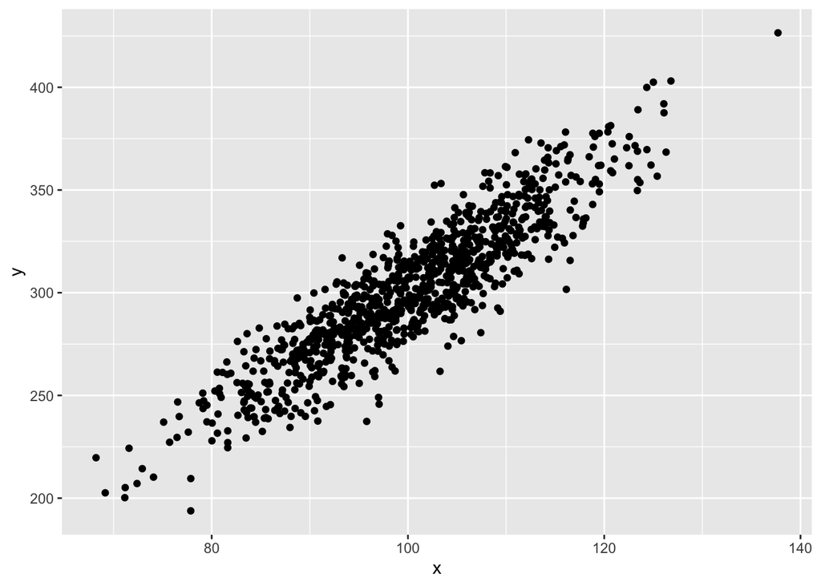

```r
ggplot(d, aes(x = x, y = y)) + geom_point()
```

Run a linear regression:

```r
model1 <- lm(y ~ x, data = d)

summary(model1)
```

```
##
## Call:
## lm(formula = y ~ x, data = d)
##
## Residuals:
##     Min      1Q  Median      3Q     Max
## -50.042  -9.800  -0.026  10.450  44.128
##
## Coefficients:
##             Estimate Std. Error t value Pr(>|t|)
## (Intercept) -1.35761    4.56514  -0.297    0.766
## x            3.01413    0.04537  66.432   <2e-16 ***
## ---
## Signif. codes:  0 '***' 0.001 '**' 0.01 '*' 0.05 '.' 0.1 ' ' 1
##
## Residual standard error: 14.61 on 998 degrees of freedom
## Multiple R-squared:  0.8156, Adjusted R-squared:  0.8154
## F-statistic:  4413 on 1 and 998 DF,  p-value: < 2.2e-16
```

Reading and writing CSV data:

```r
if (!dir.exists("data")) {
  dir.create("data")
}

write_csv(d, "data/random_data.csv")

d <- read_csv("data/random_data.csv")
```

# RMarkdown homework template

Let’s go together to this url:  
https://github.com/zalmquist/SOC506/tree/master/Homeworks/homework_template

If time allows, we’ll talk through some of the code in the template.

# Resources

Soc 505 R mini-lectures:

- https://ccgilroy.github.io/r-intro/
- https://ccgilroy.github.io/r-habits/
- https://ccgilroy.github.io/r-modelviz/

CSSS 508 (Chuck Lanfear): https://clanfear.github.io/CSSS508/